# Preventing Churn at Telco

## Data Visualization

Before, making our models we wanted to look at some visualizations to better understand our data and perhaps identify certain variables which should be, or will be, significant in predicting churn. For customer demographics, we observe that customers are split relatively 50-50 based on gender and that about 2000 customers out of the 10000 were senior citizens. As for services, the graphics reveal that phone and internet packages are the most popular. Customers with longer contracts tend to purchase more services. While most customers pay month-by-month, customers with longer contracts tend to have lower average monthly bills. Finally, when visualizing churn data, we can note that customers that leave Telco have a higher median average monthly bill, but purchase roughly the same number of services.

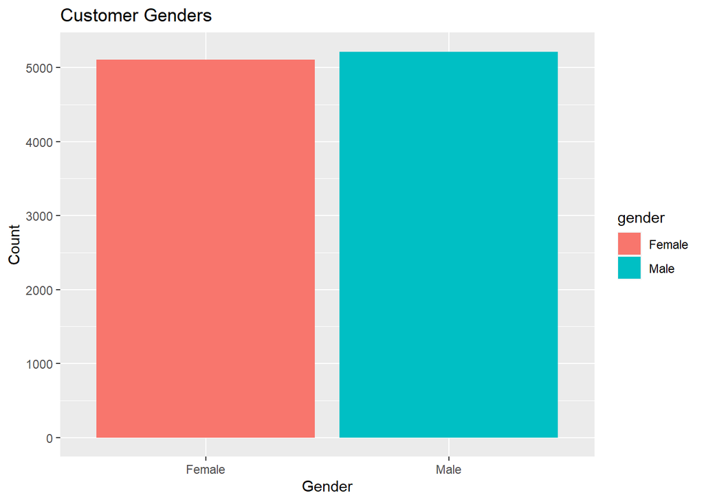

```r
#Exploring Gender and Senior Citizens
cdata %>% ggplot(.) + geom_histogram(aes(x = gender, fill = gender), stat = "count") + ggtitle("Customer Genders") + xlab("Gender") + ylab("Count")
```

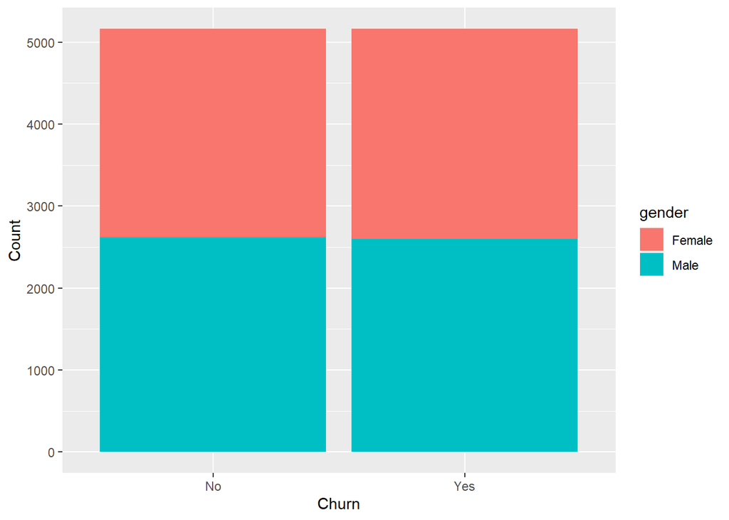

```r
cdata %>% group_by(Churn,gender) %>% summarise(count = n()) %>% ggplot(.) + geom_col(aes(x=Churn, y = count, fill = gender)) + xlab("Churn") + ylab("Count")
```

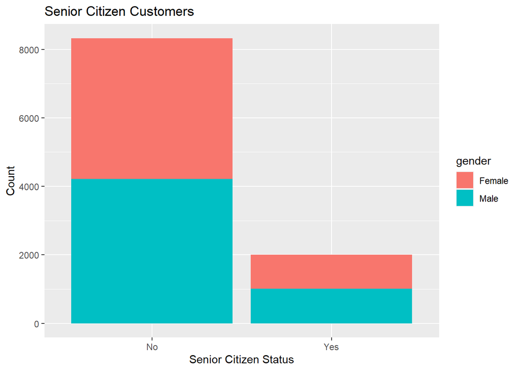

```r
cdata %>% ggplot(.) + geom_histogram(aes(x=ifelse(as.factor(SeniorCitizen) == 1, "Yes", "No"), fill = gender),  stat = "count") + ggtitle("Senior Citizen Customers") + xlab("Senior Citizen Status") + ylab("Count")
```

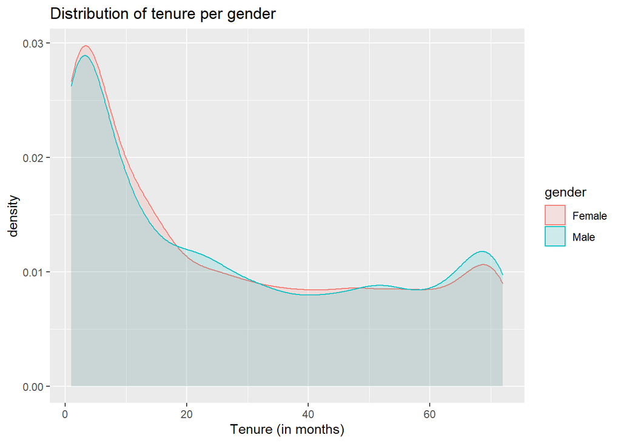

```r
#Exploring Tenure
cdata %>% ggplot(.)  + geom_density(aes(tenure,group=gender, fill=gender, colour=gender), alpha=0.15) + ggtitle("Distribution of tenure per gender") + xlab("Tenure (in months)")
```

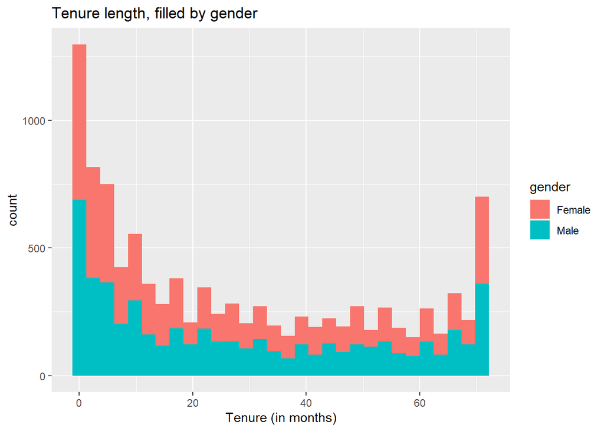

```r
cdata %>% ggplot(.) + geom_histogram(aes(x = tenure, fill = gender)) + ggtitle("Tenure length, filled by gender") + xlab("Tenure (in months)")
```

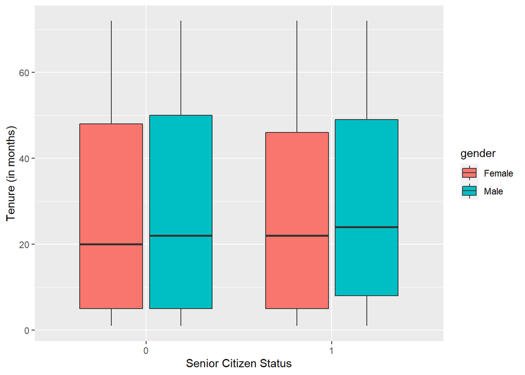

```r
cdata %>% ggplot(.) + geom_boxplot(aes(x = as.factor(SeniorCitizen), y = tenure, fill = gender)) + xlab("Senior Citizen Status") + ylab("Tenure (in months)")
```

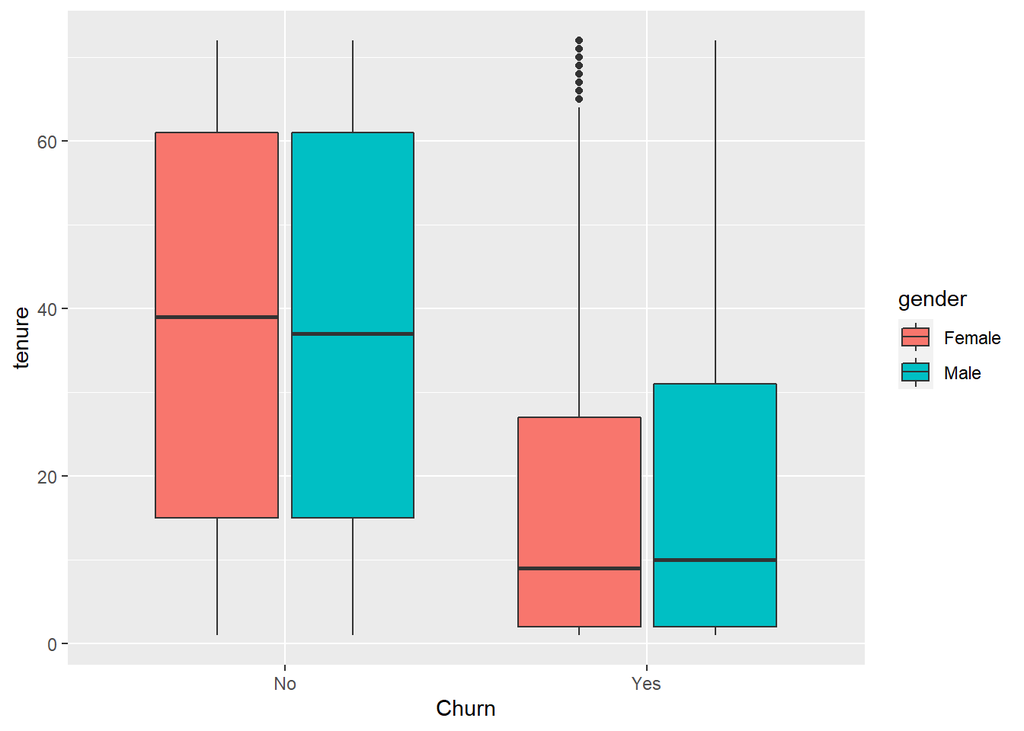

```r
cdata %>% ggplot(.) + geom_boxplot(aes(x = Churn, y = tenure, fill= gender))
```

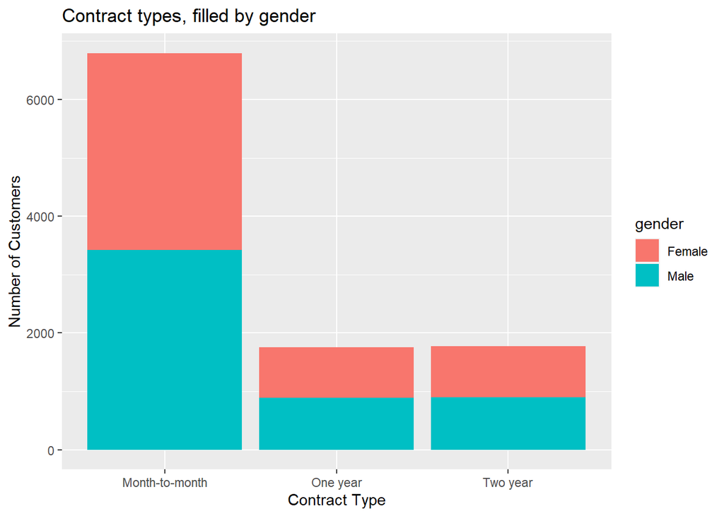

```r
#Exploring Contract Types
cdata %>% ggplot(.) + geom_histogram(aes(x = Contract, fill = gender), stat = "count") + ggtitle("Contract types, filled by gender") + xlab("Contract Type") + ylab("Number of Customers")
```

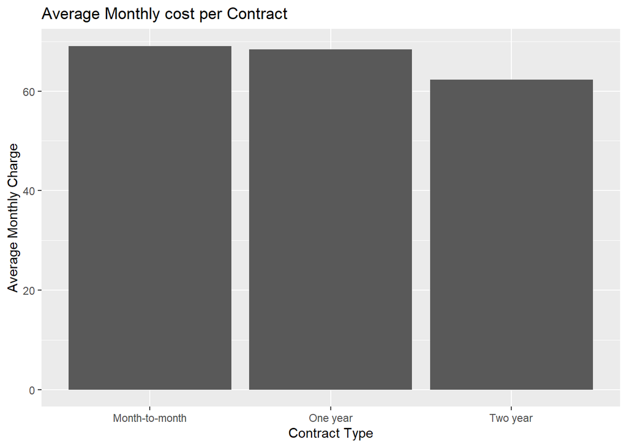

```r
cdata %>% group_by(Contract) %>% summarise(avg = mean(MonthlyCharges)) %>% ggplot(.) + geom_col(aes(x=Contract, y = avg)) + xlab("Contract Type") + ylab("Average Monthly Charge") + ggtitle("Average Monthly cost per Contract")
```

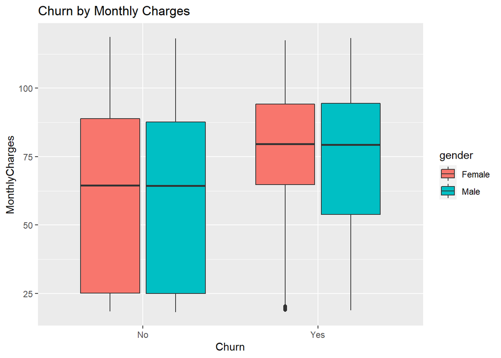

```r
cdata %>% ggplot(.) + geom_boxplot(aes(x = Churn, y = MonthlyCharges, fill = gender)) + ggtitle("Churn by Monthly Charges")
```

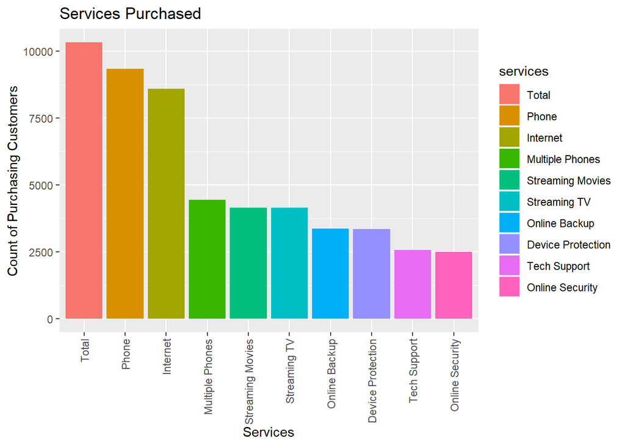

```r
#Exploring Number of Services

services <- c("Total", "Phone", "Multiple Phones", "Internet", "Online Security", "Online Backup", "Device Protection", "Tech Support", "Streaming TV", "Streaming Movies")

counts <- c(nrow(cdata[,]), nrow(cdata[cdata$PhoneService == "Yes", ]), nrow(cdata[cdata$MultipleLines == "Yes", ]), nrow(cdata[cdata$InternetService != "No", ]),nrow(cdata[cdata$OnlineSecurity == "Yes", ]),nrow(cdata[cdata$OnlineBackup == "Yes", ]),nrow(cdata[cdata$DeviceProtection == "Yes", ]),nrow(cdata[cdata$TechSupport == "Yes", ]),nrow(cdata[cdata$StreamingTV == "Yes", ]),nrow(cdata[cdata$StreamingMovies == "Yes", ]))

countserv <- data.frame(services, counts)
countserv$services  <- with(countserv, reorder(services, -counts))

countserv %>% ggplot(.) + geom_col(aes(x=services, y = counts, fill = services)) + xlab("Services") + ylab("Count of Purchasing Customers") + theme(axis.text.x = element_text(angle = 90, vjust = 0.5, hjust=1)) + ggtitle("Services Purchased")
```

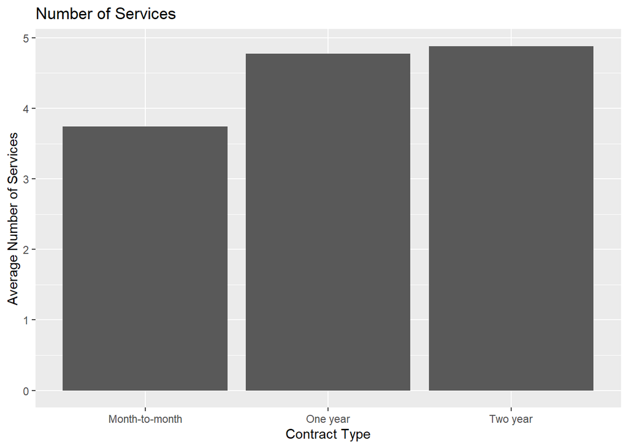

```r
cdata %>% group_by(Contract) %>% summarise(avg = mean(NumServices)) %>% ggplot(.) + geom_col(aes(x=Contract, y = avg)) + xlab("Contract Type") + ylab("Average Number of Services") + ggtitle("Number of Services")
```

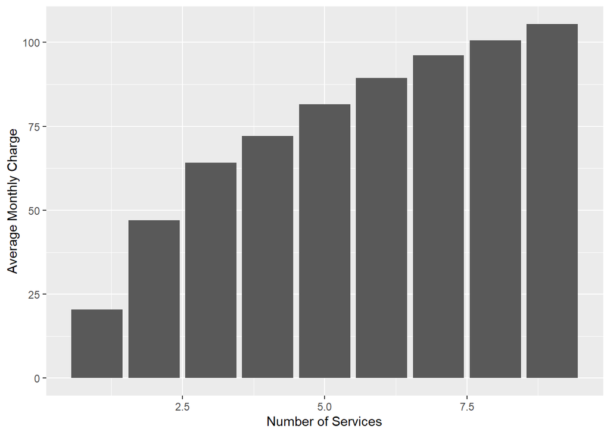

```r
cdata %>% group_by(NumServices) %>% summarise(avg = mean(MonthlyCharges)) %>% ggplot(.) + geom_col(aes(x=NumServices, y = avg)) + xlab("Number of Services") + ylab("Average Monthly Charge")
```

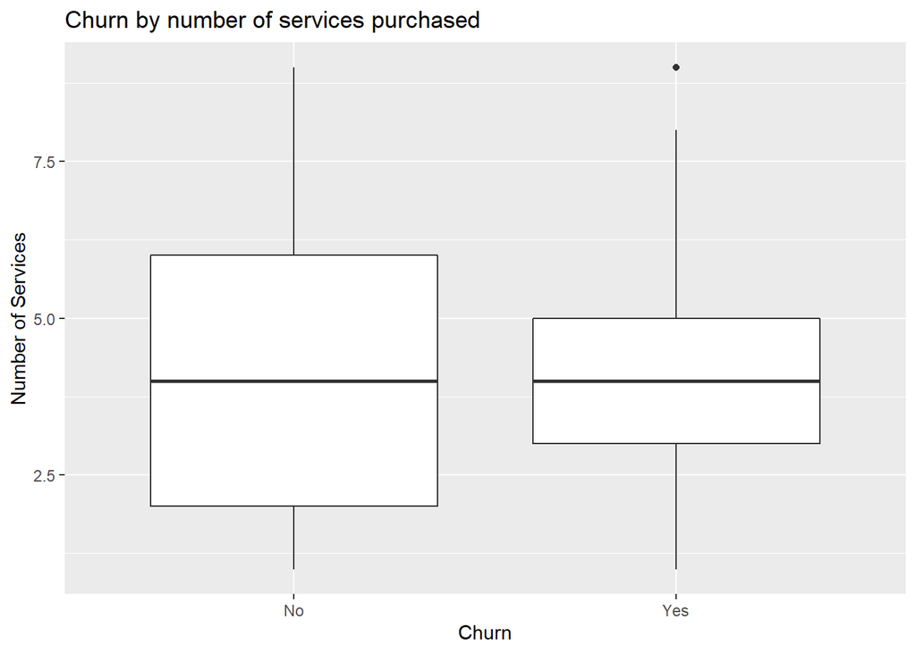

```r
cdata %>% ggplot(.) + geom_boxplot(aes(x = as.factor(Churn), y = NumServices)) + xlab("Churn") + ylab("Number of Services") + ggtitle("Churn by number of services purchased")
```

## Models

In this following section, we are going to be generating models with the goal of predicting customer churn and better understanding the significant predictors.

### Logistic Regression Model

The first model we created was a logistic regression model. This model uses a logistic function to model a binary response variables based on explanatory variables. We wanted to create this initial model to help us understand if there were any insignificant variables that we should be removing from our models and also to get an idea of which predictors are stronger than others. We also optimized this model using a backwards step wise function.

```r
#First model
c_train_labels_numeric <- ifelse(c_train_labels == "Yes", 1, 0)
c_test_labels_numeric <- ifelse(c_test_labels == "Yes", 1, 0)

glm1 <- glm(c_train_labels_numeric ~ ., data = c_train, family = binomial)
summary(glm1)
```

```
##
## Call:
## glm(formula = c_train_labels_numeric ~ ., family = binomial,
##     data = c_train)
##
## Deviance Residuals:
##     Min       1Q   Median       3Q      Max
## -2.3868  -0.7281   0.3937   0.7153   2.9236
##
## Coefficients: (1 not defined because of singularities)
##                                        Estimate Std. Error z value Pr(>|z|)
## (Intercept)                           3.124e+00  9.047e-01   3.454 0.000553 ***
## genderMale                            4.177e-02  7.093e-02   0.589 0.555976
## SeniorCitizen                         2.660e-01  9.476e-02   2.807 0.004996 **
## PartnerYes                            3.611e-02  8.633e-02   0.418 0.675725
## DependentsYes                        -1.331e-01  9.715e-02  -1.370 0.170813
## tenure                               -5.957e-02  5.939e-03 -10.030  < 2e-16 ***
## PhoneServiceYes                       4.142e-01  7.135e-01   0.580 0.561583
## MultipleLinesYes                      5.763e-01  1.949e-01   2.957 0.003105 **
## InternetServiceFiber optic            2.458e+00  8.756e-01   2.808 0.004989 **
## InternetServiceNo                    -2.299e+00  8.862e-01  -2.595 0.009472 **
## OnlineSecurityYes                    -1.802e-01  1.941e-01  -0.929 0.353118
## OnlineBackupYes                       1.515e-01  1.931e-01   0.785 0.432578
## DeviceProtectionYes                   1.909e-01  1.940e-01   0.984 0.325032
## TechSupportYes                       -5.590e-03  1.962e-01  -0.028 0.977269
## StreamingTVYes                        8.280e-01  3.588e-01   2.308 0.021021 *
## StreamingMoviesYes                    8.660e-01  3.614e-01   2.397 0.016552 *
## ContractOne year                     -7.482e-01  1.106e-01  -6.767 1.31e-11 ***
## ContractTwo year                     -1.291e+00  1.591e-01  -8.114 4.92e-16 ***
## PaperlessBillingYes                   3.956e-01  7.904e-02   5.006 5.57e-07 ***
## PaymentMethodCredit card (automatic) -2.032e-01  1.183e-01  -1.718 0.085780 .
## PaymentMethodElectronic check         2.312e-01  1.005e-01   2.300 0.021427 *
## PaymentMethodMailed check            -2.221e-01  1.216e-01  -1.827 0.067636 .
## MonthlyCharges                       -6.695e-02  3.493e-02  -1.917 0.055260 .
## TotalCharges                          3.448e-04  6.861e-05   5.026 5.01e-07 ***
## NumServices                                  NA         NA      NA       NA
## ---
## Signif. codes:  0 '***' 0.001 '**' 0.01 '*' 0.05 '.' 0.1 ' ' 1
##
## (Dispersion parameter for binomial family taken to be 1)
##
##     Null deviance: 7156.3  on 5162  degrees of freedom
## Residual deviance: 4900.6  on 5139  degrees of freedom
## AIC: 4948.6
##
## Number of Fisher Scoring iterations: 5
```

```r
#Optimizing logistic regression
glm2 <- step(glm1, direction = "backward")
```

```
## Start:  AIC=4948.61
## c_train_labels_numeric ~ gender + SeniorCitizen + Partner + Dependents +
##     tenure + PhoneService + MultipleLines + InternetService +
##     OnlineSecurity + OnlineBackup + DeviceProtection + TechSupport +
##     StreamingTV + StreamingMovies + Contract + PaperlessBilling +
##     PaymentMethod + MonthlyCharges + TotalCharges + NumServices
##
##
## Step:  AIC=4948.61
## c_train_labels_numeric ~ gender + SeniorCitizen + Partner + Dependents +
##     tenure + PhoneService + MultipleLines + InternetService +
##     OnlineSecurity + OnlineBackup + DeviceProtection + TechSupport +
##     StreamingTV + StreamingMovies + Contract + PaperlessBilling +
##     PaymentMethod + MonthlyCharges + TotalCharges
##
##                    Df Deviance    AIC
## - TechSupport       1   4900.6 4946.6
## - Partner           1   4900.8 4946.8
## - PhoneService      1   4900.9 4946.9
## - gender            1   4901.0 4947.0
## - OnlineBackup      1   4901.2 4947.2
## - OnlineSecurity    1   4901.5 4947.5
## - DeviceProtection  1   4901.6 4947.6
## - Dependents        1   4902.5 4948.5
## <none>                  4900.6 4948.6
## - MonthlyCharges    1   4904.3 4950.3
## - StreamingTV       1   4905.9 4951.9
## - StreamingMovies   1   4906.4 4952.4
## - InternetService   2   4908.9 4952.9
## - SeniorCitizen     1   4908.6 4954.6
## - MultipleLines     1   4909.4 4955.4
## - PaymentMethod     3   4927.3 4969.3
## - PaperlessBilling  1   4925.5 4971.5
## - TotalCharges      1   4927.3 4973.3
## - Contract          2   4985.8 5029.8
## - tenure            1   5019.7 5065.7
##
## Step:  AIC=4946.61
## c_train_labels_numeric ~ gender + SeniorCitizen + Partner + Dependents +
##     tenure + PhoneService + MultipleLines + InternetService +
```

[output cut: 152 more lines]

```
##
##                    Df Deviance    AIC
## <none>                  4905.9 4939.9
## - OnlineSecurity    1   4915.1 4947.1
## - SeniorCitizen     1   4915.6 4947.6
## - PaymentMethod     3   4933.8 4961.8
## - MultipleLines     1   4930.4 4962.4
## - PaperlessBilling  1   4931.6 4963.6
## - TotalCharges      1   4933.7 4965.7
## - StreamingTV       1   4941.0 4973.0
## - StreamingMovies   1   4944.1 4976.1
## - MonthlyCharges    1   4966.0 4998.0
## - Contract          2   4999.5 5029.5
## - tenure            1   5027.1 5059.1
## - InternetService   2   5033.7 5063.7
```

```r
#Looking at model
summary(glm2)
```

```
##
## Call:
## glm(formula = c_train_labels_numeric ~ SeniorCitizen + tenure +
##     MultipleLines + InternetService + OnlineSecurity + StreamingTV +
##     StreamingMovies + Contract + PaperlessBilling + PaymentMethod +
##     MonthlyCharges + TotalCharges, family = binomial, data = c_train)
##
## Deviance Residuals:
##     Min       1Q   Median       3Q      Max
## -2.3925  -0.7312   0.3932   0.7145   2.9227
##
## Coefficients:
##                                        Estimate Std. Error z value Pr(>|z|)
## (Intercept)                           2.623e+00  3.132e-01   8.375  < 2e-16 ***
## SeniorCitizen                         2.887e-01  9.314e-02   3.099  0.00194 **
## tenure                               -5.926e-02  5.858e-03 -10.116  < 2e-16 ***
## MultipleLinesYes                      4.794e-01  9.716e-02   4.933 8.08e-07 ***
## InternetServiceFiber optic            1.968e+00  1.935e-01  10.173  < 2e-16 ***
## InternetServiceNo                    -1.799e+00  1.933e-01  -9.305  < 2e-16 ***
## OnlineSecurityYes                    -2.928e-01  9.592e-02  -3.053  0.00226 **
## StreamingTVYes                        6.316e-01  1.077e-01   5.866 4.47e-09 ***
## StreamingMoviesYes                    6.646e-01  1.087e-01   6.113 9.79e-10 ***
## ContractOne year                     -7.701e-01  1.096e-01  -7.026 2.12e-12 ***
## ContractTwo year                     -1.325e+00  1.566e-01  -8.460  < 2e-16 ***
## PaperlessBillingYes                   4.013e-01  7.890e-02   5.086 3.65e-07 ***
## PaymentMethodCredit card (automatic) -2.064e-01  1.179e-01  -1.750  0.08009 .
## PaymentMethodElectronic check         2.396e-01  1.003e-01   2.389  0.01689 *
## PaymentMethodMailed check            -2.207e-01  1.212e-01  -1.821  0.06867 .
## MonthlyCharges                       -4.673e-02  6.165e-03  -7.580 3.45e-14 ***
## TotalCharges                          3.498e-04  6.832e-05   5.120 3.05e-07 ***
## ---
## Signif. codes:  0 '***' 0.001 '**' 0.01 '*' 0.05 '.' 0.1 ' ' 1
##
## (Dispersion parameter for binomial family taken to be 1)
##
##     Null deviance: 7156.3  on 5162  degrees of freedom
## Residual deviance: 4905.9  on 5146  degrees of freedom
## AIC: 4939.9
##
## Number of Fisher Scoring iterations: 5
```

```r
#Predicting based off of model
prediction <- predict(glm2, c_test, type = "response")
prediction2 <- as.factor(ifelse(prediction > 0.5, 1, 0))

#Creating confusion matrix
glmmatrix <- confusionMatrix(prediction2, as.factor(c_test_labels_numeric))
```

### kNN Model

The second model built was a kNN model. The k-nearest neighbors algorithm returns class membership - in our case, churn - based upon the plurality vote of its neighbors.

```r
#Creating kNN model
knn1 <- knn(train = c_trainMatrix, test = c_testMatrix, cl = c_train_labelsMatrix, k = sqrt(nrow(c_trainMatrix)))

#Creating cross table and confusion matrix for kNN model
CrossTable(x = c_train_labelsMatrix, y = knn1, prop.chisq=FALSE)
```

```
##
##
##    Cell Contents
## |-------------------------|
## |                       N |
## |           N / Row Total |
## |           N / Col Total |
## |         N / Table Total |
## |-------------------------|
##
##
## Total Observations in Table:  5163
##
##
##                      | knn1
## c_train_labelsMatrix |         0 |         1 | Row Total |
## ---------------------|-----------|-----------|-----------|
##                    0 |       970 |      1574 |      2544 |
##                      |     0.381 |     0.619 |     0.493 |
##                      |     0.501 |     0.488 |           |
##                      |     0.188 |     0.305 |           |
## ---------------------|-----------|-----------|-----------|
##                    1 |       966 |      1653 |      2619 |
##                      |     0.369 |     0.631 |     0.507 |
##                      |     0.499 |     0.512 |           |
##                      |     0.187 |     0.320 |           |
## ---------------------|-----------|-----------|-----------|
##         Column Total |      1936 |      3227 |      5163 |
##                      |     0.375 |     0.625 |           |
## ---------------------|-----------|-----------|-----------|
##
##
```

```r
knnmatrix <- confusionMatrix(knn1, as.factor(c_test_labelsMatrix))
```

### ANN Model

The third model built was an a ANN model. An artificial neural network is a modeling tool based off of biological neural networks. We attempted to improve this model by including hidden layers which perform nonlinear transformations of inputs as they enter the neural network. This second iteration, with the hidden layers, outperformed the one without hidden layers in respect to accuracy, kappa coefficient, and sensitivity.

```r
#Creating ANN model
ann1 <- neuralnet(formula = c_train_labelsMatrix ~ . , data = c_trainMatrix)
plot(ann1)

#Computing ANN prediction values
ann_results1 <- compute(ann1, c_testMatrix)
predicted_y1 <- ann_results1$net.result
predicted_y_dummy1 <- ifelse(predicted_y1 >= 0.5, 1, 0)

#Creating cross table and confusion matrix for ANN model
CrossTable(x = c_train_labelsMatrix, y = predicted_y_dummy1,
           prop.chisq=FALSE)
```

```
##
##
##    Cell Contents
## |-------------------------|
## |                       N |
## |           N / Row Total |
## |           N / Col Total |
## |         N / Table Total |
## |-------------------------|
##
##
## Total Observations in Table:  5163
##
##
##                      | predicted_y_dummy1
## c_train_labelsMatrix |         0 |         1 | Row Total |
## ---------------------|-----------|-----------|-----------|
##                    0 |      1166 |      1378 |      2544 |
##                      |     0.458 |     0.542 |     0.493 |
##                      |     0.495 |     0.491 |           |
##                      |     0.226 |     0.267 |           |
## ---------------------|-----------|-----------|-----------|
##                    1 |      1191 |      1428 |      2619 |
##                      |     0.455 |     0.545 |     0.507 |
##                      |     0.505 |     0.509 |           |
##                      |     0.231 |     0.277 |           |
## ---------------------|-----------|-----------|-----------|
##         Column Total |      2357 |      2806 |      5163 |
##                      |     0.457 |     0.543 |           |
## ---------------------|-----------|-----------|-----------|
##
##
```

```r
annmatrix1 <- confusionMatrix(as.factor(c_test_labelsMatrix), as.factor(predicted_y_dummy1))

ann2 <- neuralnet(formula = c_train_labelsMatrix ~ . , data = c_trainMatrix, hidden = 3)
plot(ann2)

#Computing ANN prediction values
ann_results2 <- compute(ann2, c_testMatrix)
predicted_y2 <- ann_results2$net.result
predicted_y_dummy2 <- ifelse(predicted_y2 >= 0.5, 1, 0)

#Creating cross table and confusion matrix for ANN model
CrossTable(x = c_train_labelsMatrix, y = predicted_y_dummy2,
           prop.chisq=FALSE)
```

```
##
##
##    Cell Contents
## |-------------------------|
## |                       N |
## |           N / Row Total |
## |           N / Col Total |
## |         N / Table Total |
## |-------------------------|
##
##
## Total Observations in Table:  5163
##
##
##                      | predicted_y_dummy2
## c_train_labelsMatrix |         0 |         1 | Row Total |
## ---------------------|-----------|-----------|-----------|
##                    0 |      1162 |      1382 |      2544 |
##                      |     0.457 |     0.543 |     0.493 |
##                      |     0.495 |     0.491 |           |
##                      |     0.225 |     0.268 |           |
## ---------------------|-----------|-----------|-----------|
##                    1 |      1184 |      1435 |      2619 |
##                      |     0.452 |     0.548 |     0.507 |
##                      |     0.505 |     0.509 |           |
##                      |     0.229 |     0.278 |           |
## ---------------------|-----------|-----------|-----------|
##         Column Total |      2346 |      2817 |      5163 |
##                      |     0.454 |     0.546 |           |
## ---------------------|-----------|-----------|-----------|
##
##
```

```r
annmatrix2 <- confusionMatrix(as.factor(c_test_labelsMatrix), as.factor(predicted_y_dummy2))

annmatrix <- annmatrix2
```

### SVM

Additionally, an SVM model was built. Support Vector Machines are typically used to carry out general regression and classification. Multiple kernel functions (Polynomial, Laplacian, and Radial Basis) were used to determine which would yield the SVM model the best results. The Radial Basis kernel function resulted in the greatest accuracy, kappa coefficient, and specificity. As a result, we concluded that the Radial Basis kernel function yielded the best SVM model.

```r
#Creating SVM model (polydot)
svm_poly <- ksvm(c_train_labelsMatrix ~ ., data = c_trainMatrix,
                          kernel = "polydot")
svmpred_poly <- predict(svm_poly, c_testMatrix)
svmpred_poly <- ifelse(svmpred_poly >= 0.5, 1, 0)
#Creating polydot confusion matrix
svmmatrix_poly <- confusionMatrix(as.factor(c_test_labelsMatrix), as.factor(svmpred_poly))

#Creating SVM model (laplace)
svm_laplace <- ksvm(c_train_labelsMatrix ~ ., data = c_trainMatrix,
                          kernel = "laplacedot")
svmpred_laplace <- predict(svm_laplace, c_testMatrix)
svmpred_laplace <- ifelse(svmpred_laplace >= 0.5, 1, 0)
#Creating laplace confusion matrix
svmmatrix_laplace <- confusionMatrix(as.factor(c_test_labelsMatrix), as.factor(svmpred_laplace))

#Creating SVM model (rdfdot)
svm_rbf <- ksvm(c_train_labelsMatrix ~ ., data = c_trainMatrix,
                          kernel = "rbfdot")
svmpred_rbf <- predict(svm_rbf, c_testMatrix)
svmpred_rbf <- ifelse(svmpred_rbf >= 0.5, 1, 0)
#Creating rdfdot confusion matrix
svmmatrix_rbf <- confusionMatrix(as.factor(c_test_labelsMatrix), as.factor(svmpred_rbf))

#Finding out which SVM model worked the best
svmmatrix_poly
```

```
## Confusion Matrix and Statistics
##
##           Reference
## Prediction    0    1
##          0 1464 1155
##          1  282 2262
##
##                Accuracy : 0.7217
##                  95% CI : (0.7092, 0.7339)
##     No Information Rate : 0.6618
##     P-Value [Acc > NIR] : < 2.2e-16
##
##                   Kappa : 0.446
##
##  Mcnemar's Test P-Value : < 2.2e-16
##
##             Sensitivity : 0.8385
##             Specificity : 0.6620
##          Pos Pred Value : 0.5590
##          Neg Pred Value : 0.8892
##              Prevalence : 0.3382
##          Detection Rate : 0.2836
##    Detection Prevalence : 0.5073
##       Balanced Accuracy : 0.7502
##
##        'Positive' Class : 0
##
```

```r
svmmatrix_laplace
```

```
## Confusion Matrix and Statistics
##
##           Reference
## Prediction    0    1
##          0 1770  849
##          1  418 2126
##
##                Accuracy : 0.7546
##                  95% CI : (0.7426, 0.7663)
##     No Information Rate : 0.5762
##     P-Value [Acc > NIR] : < 2.2e-16
##
##                   Kappa : 0.5103
##
##  Mcnemar's Test P-Value : < 2.2e-16
##
##             Sensitivity : 0.8090
##             Specificity : 0.7146
##          Pos Pred Value : 0.6758
##          Neg Pred Value : 0.8357
##              Prevalence : 0.4238
##          Detection Rate : 0.3428
##    Detection Prevalence : 0.5073
##       Balanced Accuracy : 0.7618
##
##        'Positive' Class : 0
##
```

```r
svmmatrix_rbf
```

```
## Confusion Matrix and Statistics
##
##           Reference
## Prediction    0    1
##          0 1879  740
##          1  460 2084
##
##                Accuracy : 0.7676
##                  95% CI : (0.7558, 0.779)
##     No Information Rate : 0.547
##     P-Value [Acc > NIR] : < 2.2e-16
##
##                   Kappa : 0.5358
##
##  Mcnemar's Test P-Value : 8.011e-16
##
##             Sensitivity : 0.8033
##             Specificity : 0.7380
##          Pos Pred Value : 0.7174
##          Neg Pred Value : 0.8192
##              Prevalence : 0.4530
##          Detection Rate : 0.3639
##    Detection Prevalence : 0.5073
##       Balanced Accuracy : 0.7706
##
##        'Positive' Class : 0
##
```

```r
svmmatrix <- svmmatrix_rbf
```

### Decision Tree

Finally, a decision tree model was built. In this algorithm, a sequence of tests are done adaptively, in which the result from a previous test determines the test next performed. We attempted to improve this model by using significant variables from the logistic regression model; however, multiple R issues prevented us from doing so.

[figure not shown]

```r
#Creating decision tree model
mod1 <- C5.0(c_train_labels ~ ., data = c_train)
plot(mod1)
```

```r
summary(mod1)
```

```
##
## Call:
## C5.0.formula(formula = c_train_labels ~ ., data = c_train)
##
##
## C5.0 [Release 2.07 GPL Edition]      Sun Dec 12 19:02:43 2021
## -------------------------------
##
## Class specified by attribute `outcome'
##
## Read 5163 cases (21 attributes) from undefined.data
##
## Decision tree:
##
## Contract = Month-to-month:
## :...InternetService = Fiber optic:
## :   :...tenure <= 15:
## :   :   :...tenure <= 1:
## :   :   :   :...TechSupport = No: Yes (305/9)
## :   :   :   :   TechSupport = Yes:
## :   :   :   :   :...Partner = No: No (5/1)
## :   :   :   :       Partner = Yes: Yes (2)
## :   :   :   tenure > 1:
## :   :   :   :...OnlineSecurity = No: Yes (759/114)
## :   :   :       OnlineSecurity = Yes:
## :   :   :       :...NumServices > 5: Yes (32/2)
## :   :   :           NumServices <= 5:
## :   :   :           :...MonthlyCharges > 89: No (8)
## :   :   :               MonthlyCharges <= 89:
## :   :   :               :...StreamingTV = Yes: Yes (10)
## :   :   :                   StreamingTV = No:
## :   :   :                   :...gender = Female: Yes (24/6)
## :   :   :                       gender = Male:
## :   :   :                       :...TechSupport = No: No (13/4)
## :   :   :                           TechSupport = Yes: Yes (2)
## :   :   tenure > 15:
## :   :   :...tenure > 54:
## :   :       :...StreamingTV = Yes:
## :   :       :   :...TechSupport = No: Yes (66/26)
## :   :       :   :   TechSupport = Yes: No (15/4)
```

[output cut: 211 more lines]

```
##   17.39% TechSupport
##   16.42% OnlineSecurity
##   16.35% PhoneService
##   15.49% SeniorCitizen
##   11.02% NumServices
##    7.63% Partner
##    7.48% OnlineBackup
##    6.99% TotalCharges
##    4.45% DeviceProtection
##    3.39% StreamingTV
##    2.36% gender
##    1.38% Dependents
##
##
## Time: 0.0 secs
```

```r
#Creating prediction from decision tree model
treepred <- predict(mod1, c_test)
treematrix <- confusionMatrix(as.factor(c_test_labels), treepred)

#Creating second decision tree model
#mod2 <- C5.0(c_train_labels ~ senior_citizen + dependents_yes + tenure +
#                    multiple_lines_yes + internet_service_fiber_optic + internet_service_no +
#                    online_security_yes + tech_support_yes + streaming_tv_yes + streaming_movies_yes +
#                    contract_one_year + contract_two_year + paperless_billing_yes +
#                    payment_method_electronic_check + monthly_charges + total_charges, data = c_train)
#plot(mod2)
#summary(mod2)

#Creating prediction from the second decision tree model
#treepred2 <- predict(mod2, telcomatrix_jan)
#treematrix2 <- confusionMatrix(as.factor(telcomatrix_jan$churn_yes), treepred2)

#Finding out which decision tree matrix worked the best
treematrix
```

```
## Confusion Matrix and Statistics
##
##           Reference
## Prediction   No  Yes
##        No  1860  759
##        Yes  408 2136
##
##                Accuracy : 0.774
##                  95% CI : (0.7623, 0.7853)
##     No Information Rate : 0.5607
##     P-Value [Acc > NIR] : < 2.2e-16
##
##                   Kappa : 0.5487
##
##  Mcnemar's Test P-Value : < 2.2e-16
##
##             Sensitivity : 0.8201
##             Specificity : 0.7378
##          Pos Pred Value : 0.7102
##          Neg Pred Value : 0.8396
##              Prevalence : 0.4393
##          Detection Rate : 0.3603
##    Detection Prevalence : 0.5073
##       Balanced Accuracy : 0.7790
##
##        'Positive' Class : No
##
```

```r
#treematrix2
```

### Stacked Model

We then combined the results from the all the models to build a stacked decision tree model. The results of this model would depends upon the outputs of the aforementioned models. To do this, we split the combined data into train and test data sets. Then a decision tree model was built upon the train data and tested upon the test data.

```r
#Creating combining prediction vector
stacked <- data.frame(c_test_labelsMatrix, prediction2, knn1, predicted_y_dummy2, treepred, svmpred_rbf)
names(stacked) <- c("Actual", "GLM", "KNN", "ANN", "TREE", "SVM")

#Manging data
stacked$Actual <- as.factor(stacked$Actual)
stacked$ANN <- as.factor(stacked$ANN)
stacked$SVM <- as.factor(stacked$SVM)
stacked$TREE <- as.factor(ifelse(stacked$TREE == "Yes", 1, 0))

#Examining struture of dataframe
str(stacked)
```

```
## 'data.frame':    5163 obs. of  6 variables:
##  $ Actual: Factor w/ 2 levels "0","1": 2 1 2 1 1 1 2 1 2 2 ...
##  $ GLM   : Factor w/ 2 levels "0","1": 2 1 1 1 1 1 2 1 2 2 ...
##  $ KNN   : Factor w/ 2 levels "0","1": 2 1 1 1 1 1 2 1 2 2 ...
##  $ ANN   : Factor w/ 2 levels "0","1": 2 1 1 2 1 1 2 1 2 1 ...
##  $ TREE  : Factor w/ 2 levels "0","1": 2 1 1 1 1 1 2 1 2 2 ...
##  $ SVM   : Factor w/ 2 levels "0","1": 2 1 1 1 1 1 2 1 2 2 ...
```

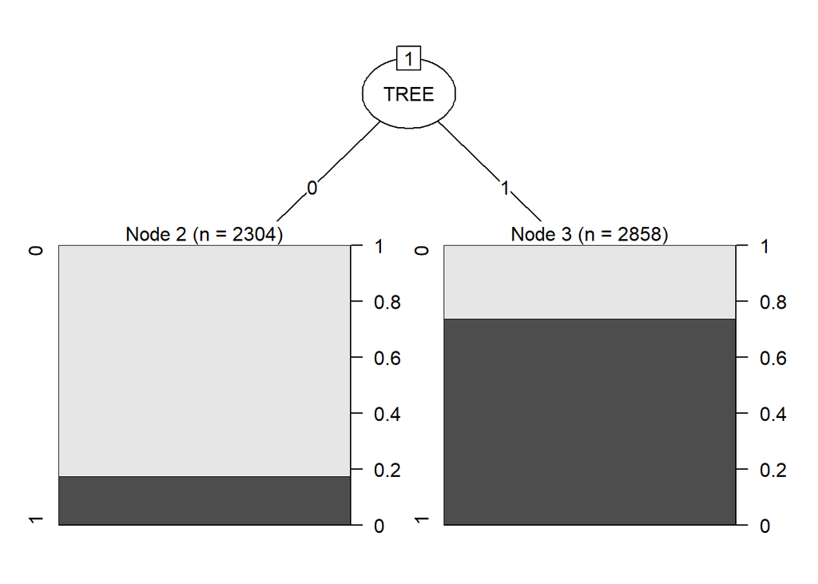

```r
#Creating test and train sets
stacked_train <- stacked[1:nrow(stacked)*3/4, ]
stacked_test  <- stacked[nrow(stacked)*3/4 + 1:nrow(stacked), ]

#Creating decision tree on the train set
dectree <- C5.0(Actual ~ ., data = stacked_train)
plot(dectree)
```

```r
summary(dectree)
```

```
##
## Call:
## C5.0.formula(formula = Actual ~ ., data = stacked_train)
##
##
## C5.0 [Release 2.07 GPL Edition]      Sun Dec 12 19:02:51 2021
## -------------------------------
##
## Class specified by attribute `outcome'
##
## Read 5162 cases (6 attributes) from undefined.data
##
## Decision tree:
##
## TREE = 0: 0 (2304/401)
## TREE = 1: 1 (2858/755)
##
##
## Evaluation on training data (5162 cases):
##
##      Decision Tree
##    ----------------
##    Size      Errors
##
##       2 1156(22.4%)   <<
##
##
##     (a)   (b)    <-classified as
##    ----  ----
##    1903   755    (a): class 0
##     401  2103    (b): class 1
##
##
##  Attribute usage:
##
##  100.00% TREE
##
##
## Time: 0.0 secs
```

```r
#Predicting the test data
dectreepred <- predict(dectree, stacked_test)
stackedmatrix <- confusionMatrix(stacked_test$Actual, dectreepred)

#Creating confusion matrix for stacked model
stackedmatrix
```

```
## Confusion Matrix and Statistics
##
##           Reference
## Prediction   0   1
##          0 428 186
##          1 115 562
##
##                Accuracy : 0.7668
##                  95% CI : (0.7428, 0.7897)
##     No Information Rate : 0.5794
##     P-Value [Acc > NIR] : < 2.2e-16
##
##                   Kappa : 0.5301
##
##  Mcnemar's Test P-Value : 5.466e-05
##
##             Sensitivity : 0.7882
##             Specificity : 0.7513
##          Pos Pred Value : 0.6971
##          Neg Pred Value : 0.8301
##              Prevalence : 0.4206
##          Detection Rate : 0.3315
##    Detection Prevalence : 0.4756
##       Balanced Accuracy : 0.7698
##
##        'Positive' Class : 0
##
```

### Majority Voting Scheme Model

In addition to the stacked decision tree model, we created a majority voting scheme model, as seen below.

```r
#Examining structure of stacked test data
str(stacked)
```

```
## 'data.frame':    5163 obs. of  6 variables:
##  $ Actual: Factor w/ 2 levels "0","1": 2 1 2 1 1 1 2 1 2 2 ...
##  $ GLM   : Factor w/ 2 levels "0","1": 2 1 1 1 1 1 2 1 2 2 ...
##  $ KNN   : Factor w/ 2 levels "0","1": 2 1 1 1 1 1 2 1 2 2 ...
##  $ ANN   : Factor w/ 2 levels "0","1": 2 1 1 2 1 1 2 1 2 1 ...
##  $ TREE  : Factor w/ 2 levels "0","1": 2 1 1 1 1 1 2 1 2 2 ...
##  $ SVM   : Factor w/ 2 levels "0","1": 2 1 1 1 1 1 2 1 2 2 ...
```

```r
#Creating majority testing structure
stacked$majority <- as.integer(stacked$GLM) + as.integer(stacked$KNN) + as.integer(stacked$ANN) +
                    as.integer(stacked$TREE) + as.integer(stacked$SVM)

#Conversion to churn or lack of churn
stacked$majority <- ifelse(stacked$majority > 8, 1, 0)

#Converting back to factor to ensure consistency
stacked$majority <- as.factor(stacked$majority)

#Creating confusion matrix for majority voting scheme model
majoritymatrix <- confusionMatrix(stacked$Actual, stacked$majority)
majoritymatrix
```

```
## Confusion Matrix and Statistics
##
##           Reference
## Prediction    0    1
##          0 1960  659
##          1  532 2012
##
##                Accuracy : 0.7693
##                  95% CI : (0.7576, 0.7808)
##     No Information Rate : 0.5173
##     P-Value [Acc > NIR] : < 2.2e-16
##
##                   Kappa : 0.5389
##
##  Mcnemar's Test P-Value : 0.0002612
##
##             Sensitivity : 0.7865
##             Specificity : 0.7533
##          Pos Pred Value : 0.7484
##          Neg Pred Value : 0.7909
##              Prevalence : 0.4827
##          Detection Rate : 0.3796
##    Detection Prevalence : 0.5073
##       Balanced Accuracy : 0.7699
##
##        'Positive' Class : 0
##
```

### Comparing all models

After creating all these models, we compiled data from the results of all to compare the models.

```r
glmmatrix$overall
```

```
##       Accuracy          Kappa  AccuracyLower  AccuracyUpper   AccuracyNull
##   7.602169e-01   5.211735e-01   7.483289e-01   7.718100e-01   5.072632e-01
## AccuracyPValue  McnemarPValue
##  7.719396e-305   9.663309e-19
```

```r
knnmatrix$overall
```

```
##       Accuracy          Kappa  AccuracyLower  AccuracyUpper   AccuracyNull
##   7.387178e-01   4.793268e-01   7.265045e-01   7.506607e-01   5.072632e-01
## AccuracyPValue  McnemarPValue
##  2.174489e-253   5.772252e-77
```

```r
annmatrix$overall
```

```
##       Accuracy          Kappa  AccuracyLower  AccuracyUpper   AccuracyNull
##   7.697075e-01   5.400246e-01   7.579758e-01   7.811336e-01   5.456130e-01
## AccuracyPValue  McnemarPValue
##  2.308945e-245   3.065733e-15
```

```r
svmmatrix_rbf$overall
```

```
##       Accuracy          Kappa  AccuracyLower  AccuracyUpper   AccuracyNull
##   7.675770e-01   5.357874e-01   7.558095e-01   7.790412e-01   5.469688e-01
## AccuracyPValue  McnemarPValue
##  8.755554e-238   8.010747e-16
```

```r
treematrix$overall
```

```
##       Accuracy          Kappa  AccuracyLower  AccuracyUpper   AccuracyNull
##   7.739686e-01   5.487333e-01   7.623097e-01   7.853170e-01   5.607205e-01
## AccuracyPValue  McnemarPValue
##  5.512359e-225   1.239985e-24
```

```r
stackedmatrix$overall
```

```
##       Accuracy          Kappa  AccuracyLower  AccuracyUpper   AccuracyNull
##   7.668474e-01   5.300532e-01   7.428019e-01   7.896714e-01   5.793958e-01
## AccuracyPValue  McnemarPValue
##   1.834569e-45   5.466444e-05
```

```r
majoritymatrix$overall
```

```
##       Accuracy          Kappa  AccuracyLower  AccuracyUpper   AccuracyNull
##   7.693202e-01   5.388726e-01   7.575819e-01   7.807532e-01   5.173349e-01
## AccuracyPValue  McnemarPValue
##  4.465563e-305   2.611970e-04
```

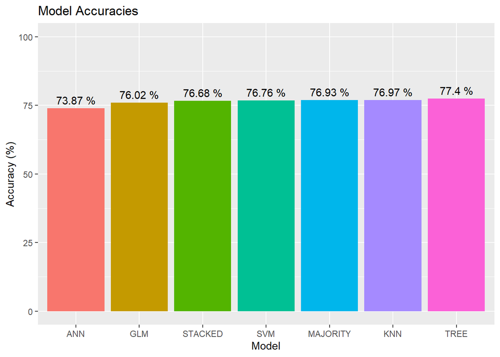

```r
accuracies <- c(glmmatrix$overall[1], knnmatrix$overall[1], annmatrix$overall[1], svmmatrix_rbf$overall[1], treematrix$overall[1], stackedmatrix$overall[1], majoritymatrix$overall[1])

kappas <- c(glmmatrix$overall[2], knnmatrix$overall[2], annmatrix$overall[2], svmmatrix_rbf$overall[2], treematrix$overall[2], stackedmatrix$overall[2], majoritymatrix$overall[2])

sensitivities <- c(glmmatrix$byClass[1], knnmatrix$byClass[1], annmatrix$byClass[1], svmmatrix_rbf$byClass[1], treematrix$byClass[1],stackedmatrix$byClass[1], majoritymatrix$byClass[1])

specificities <- c(glmmatrix$byClass[2], knnmatrix$byClass[2], annmatrix$byClass[2], svmmatrix_rbf$byClass[2], treematrix$byClass[2],stackedmatrix$byClass[2], majoritymatrix$byClass[2])

names <- c("GLM", "ANN", "KNN", "SVM", "TREE", "STACKED", "MAJORITY")
models <- data.frame(names, accuracies, kappas, sensitivities, specificities)

models %>% arrange(as.numeric(accuracies)) %>% mutate(names=factor(names, levels=names)) %>% ggplot(aes(x = as.factor(names), y = as.numeric(accuracies) * 100, fill = as.factor(names))) + geom_col(show.legend = FALSE) + ylim(0,100) + geom_text(aes(label = paste(round(as.numeric(accuracies) * 100, 2), "%"), vjust = -0.5)) + ylab("Accuracy (%)") + xlab("Model") + ggtitle("Model Accuracies")
```

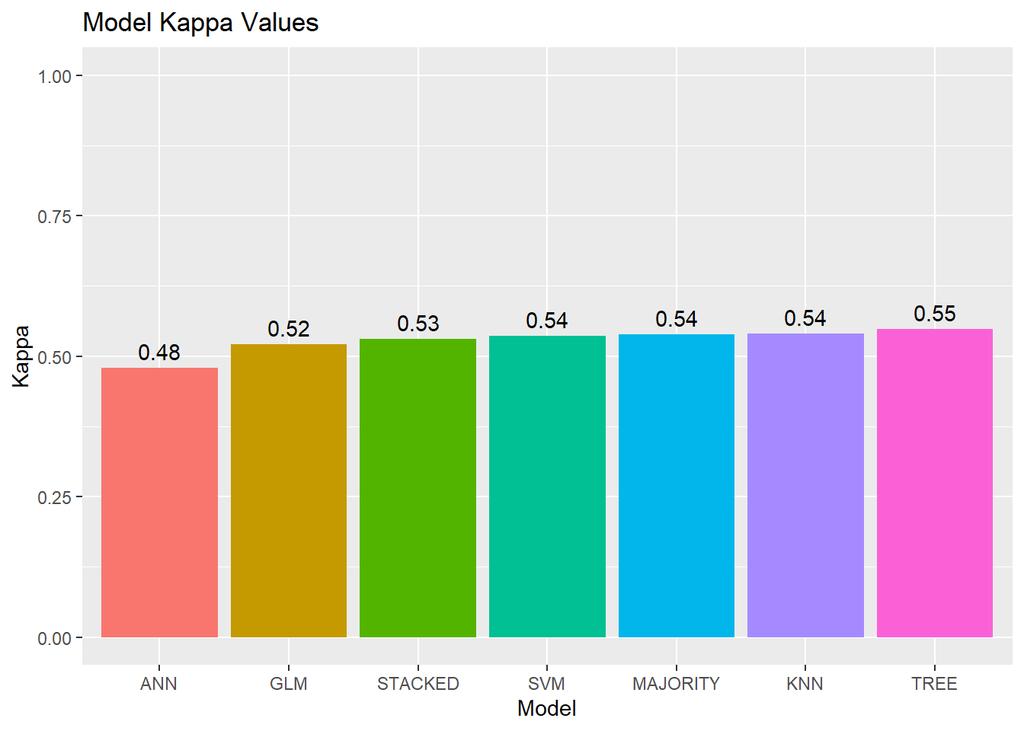

```r
models %>% arrange(as.numeric(kappas)) %>% mutate(names=factor(names, levels=names)) %>% ggplot(aes(x = as.factor(names), y = as.numeric(kappas), fill = as.factor(names))) + geom_col(show.legend = FALSE) + ylim(0,1) + geom_text(aes(label = paste(round(as.numeric(kappas), 2)), vjust = -0.5)) + ylab("Kappa") + xlab("Model") + ggtitle("Model Kappa Values")
```

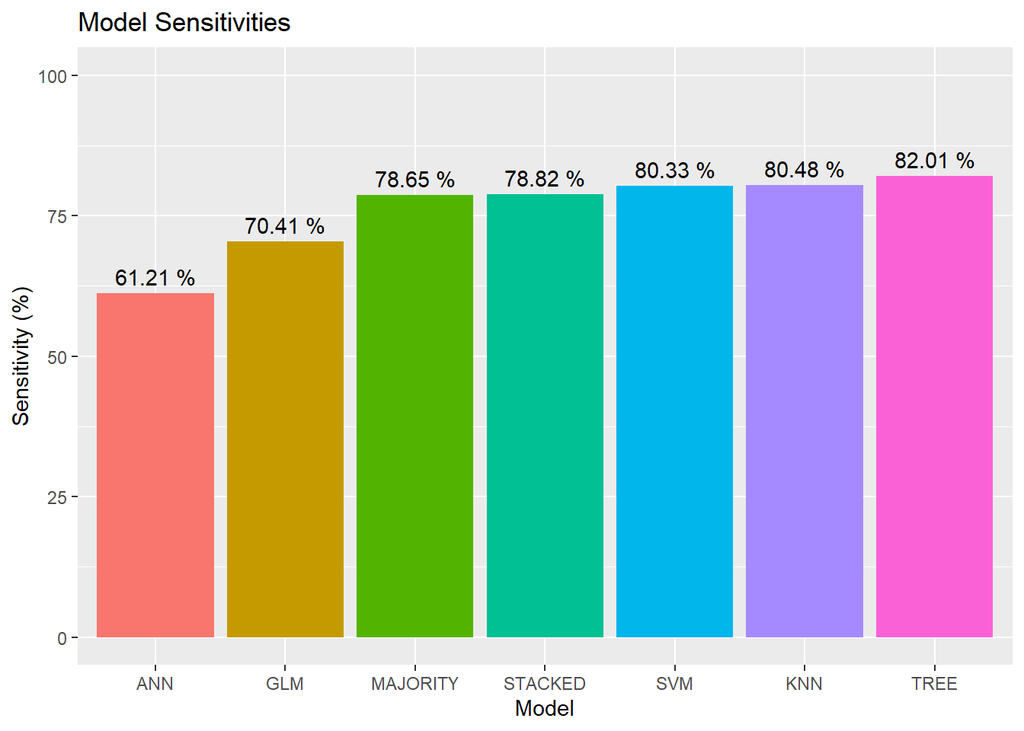

```r
models %>% arrange(as.numeric(sensitivities)) %>% mutate(names=factor(names, levels=names)) %>% ggplot(aes(x = as.factor(names), y = as.numeric(sensitivities) * 100, fill = as.factor(names))) + geom_col(show.legend = FALSE) + ylim(0,100) + geom_text(aes(label = paste(round(as.numeric(sensitivities) * 100, 2), "%"), vjust = -0.5)) + ylab("Sensitivity (%)") + xlab("Model") + ggtitle("Model Sensitivities")
```

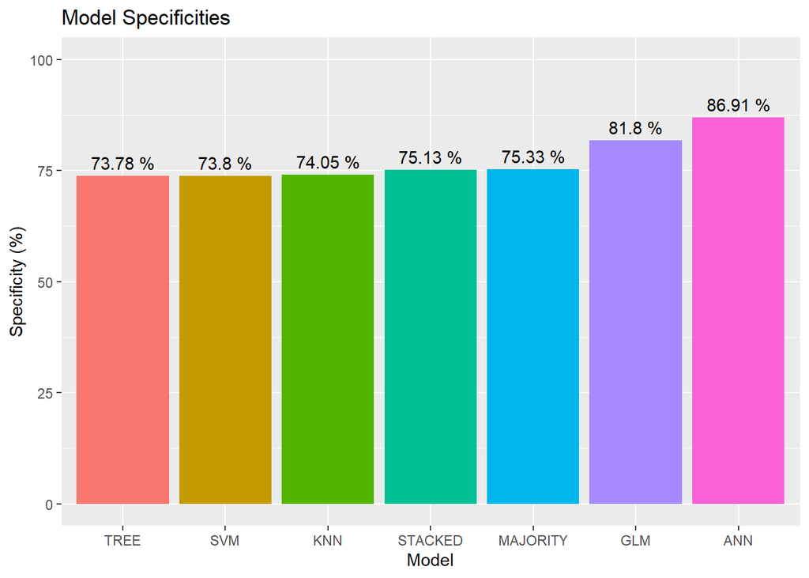

```r
models %>% arrange(as.numeric(specificities)) %>% mutate(names=factor(names, levels=names)) %>% ggplot(aes(x = as.factor(names), y = as.numeric(specificities) * 100, fill = as.factor(names))) + geom_col(show.legend = FALSE) + ylim(0,100) + geom_text(aes(label = paste(round(as.numeric(specificities) * 100, 2), "%"), vjust = -0.5)) + ylab("Specificity (%)") + xlab("Model") + ggtitle("Model Specificities")
```

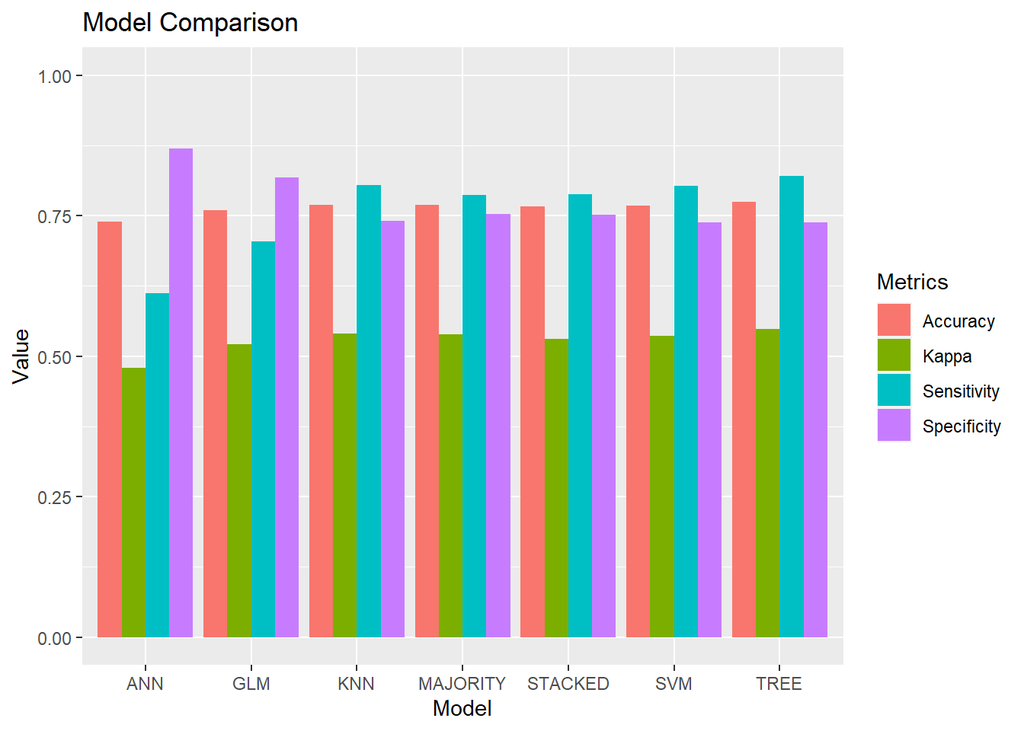

```r
modelsmelt <- melt(models ,  id.vars = 'names', variable.name = 'series')

modelsmelt %>% ggplot(aes(names, value)) + geom_bar(stat="identity", position = "dodge", aes(fill = series)) + ylim(0,1) + ggtitle("Model Comparison") + xlab("Model") + ylab("Value") + scale_fill_discrete(name = "Metrics", labels = c("Accuracy", "Kappa", "Sensitivity", "Specificity"))
```

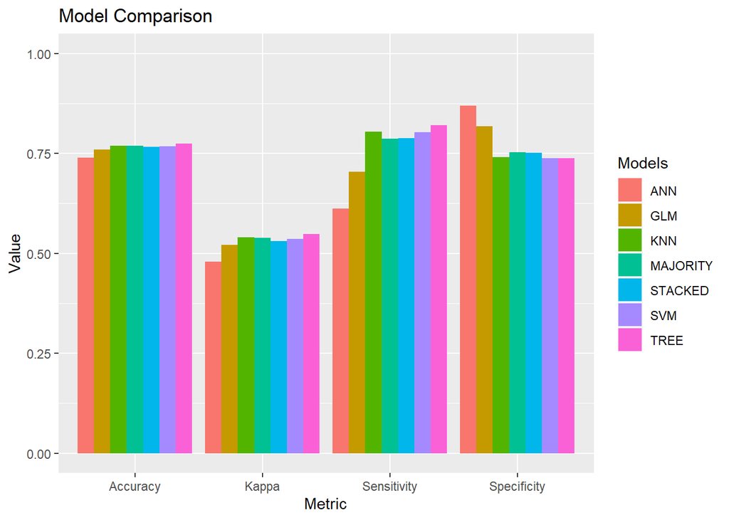

```r
modelsmelt %>% ggplot(aes(series, value)) + geom_bar(stat="identity", position = "dodge", aes(fill = names)) + ylim(0,1) + ggtitle("Model Comparison") + xlab("Metric") + ylab("Value") +  scale_fill_discrete(name = "Models") + scale_x_discrete(labels = c("Accuracy", "Kappa", "Sensitivity", "Specificity"))
```

## Conclusion

The models we created could be useful to the Telco company by predicting which current customers are most likely to churn, and thereby giving the firm an opportunity to target those customers with price promotions and/or incentives to stay.

Once the model(s) are put into use, we expect Telco’s churn numbers to go down, indicated by higher customer retention metrics (controling for things such as customers moving away, death, etc.). Since many models performed similarly, we recommend that the Telco company deploy multiple models on random subsets of customers, so that the models can be forward-tested for a bit to determine which truly performs the best in practice.